# Reflection on Trees with Group Project Data

Analytics Objective: Predict Retail Sales Revenue

Author

Mickyas Shawel

Published

August 16, 2026

# Overview

This report applies the **decision-tree workflow from the Week 9 Trees and Ensembles module** to our Group 1 retail-sales project. The analysis reframes the project as a supervised machine-learning problem and evaluates whether tree-based methods can predict transaction-level sales revenue from promotional, marketing, product, store, and calendar characteristics.

**NoteImportant metric note**

The assignment’s pruning prompt refers to **AUC**, which is a classification metric. Because this report uses a **regression tree** with continuous sales revenue as the outcome, pruning is evaluated with **RMSE and (R^2)** instead. This preserves the statistical meaning of the selected analytics objective.

# 1 Setup

## 1.1 Required packages

```r
library(tidyverse)
library(tidymodels)
library(readxl)
library(janitor)
library(lubridate)
library(rpart)
library(rpart.plot)
library(vip)
library(ranger)
library(xgboost)

tidymodels_prefer()
set.seed(617)
```

## 1.2 Import the Group Project data

> **Prompt:** Set up the QMD file with appropriate libraries and data and go through the entire machine-learning process for the analytics objective.

Place `Retail_sales.xlsx` in the same M09 project folder as this QMD file before rendering.

```r
retail <- read_excel("Retail_sales.xlsx") |>
  clean_names() |>
  rename(
    revenue      = sales_revenue_usd,
    discount_pct = discount_percentage,
    mktg_spend   = marketing_spend_usd,
    units        = units_sold,
    category     = product_category,
    location     = store_location,
    day          = day_of_the_week,
    holiday      = holiday_effect
  ) |>
  mutate(
    date = as.Date(date),
    season = case_when(
      month(date) %in% c(12, 1, 2) ~ "Winter",
      month(date) %in% c(3, 4, 5)  ~ "Spring",
      month(date) %in% c(6, 7, 8)  ~ "Summer",
      TRUE ~ "Fall"
    ),
    season = factor(season,
                    levels = c("Winter", "Spring", "Summer", "Fall")),
    holiday = factor(
      if_else(as.logical(holiday), "Holiday", "Non-Holiday")
    ),
    category = factor(category),
    location = factor(location),
    day = factor(day)
  )

glimpse(retail)
```

```
Rows: 30,000
Columns: 12
$ store_id     <chr> "Spearsland", "Spearsland", "Spearsland", "Spearsland", "…
$ product_id   <chr> "52372247", "52372247", "52372247", "52372247", "52372247…
$ date         <date> 2022-01-01, 2022-01-02, 2022-01-03, 2022-01-04, 2022-01-…
$ units        <dbl> 9, 7, 1, 4, 2, 8, 6, 9, 7, 1, 4, 6, 3, 6, 3, 2, 8, 6, 13,…
$ revenue      <dbl> 2741.69, 2665.53, 380.79, 1523.16, 761.58, 3046.32, 2284.…
$ discount_pct <dbl> 20, 0, 0, 0, 0, 0, 0, 0, 0, 0, 0, 0, 15, 0, 15, 0, 0, 0, …
$ mktg_spend   <dbl> 81, 0, 0, 0, 0, 41, 0, 83, 0, 164, 61, 0, 197, 0, 163, 16…
$ location     <fct> Tanzania, Mauritania, Saint Pierre and Miquelon, Australi…
$ category     <fct> Furniture, Furniture, Furniture, Furniture, Furniture, Fu…
$ day          <fct> Saturday, Sunday, Monday, Tuesday, Wednesday, Thursday, F…
$ holiday      <fct> Non-Holiday, Non-Holiday, Non-Holiday, Non-Holiday, Non-H…
$ season       <fct> Winter, Winter, Winter, Winter, Winter, Winter, Winter, W…
```

# 2 1. Analytics Objective

## 2.1 Prompt

> **State your AO (Analytics Objective) for your project. If your AO did not involve machine learning, revise it appropriately. State whether it is supervised or unsupervised learning, identify the outcome and features, and name the broader category of machine-learning methods.**

## 2.2 Response

### 2.2.1 Customer-oriented objective

The analytics objective is to **predict sales revenue for a retail transaction using information available about the promotion, marketing activity, product, store, and shopping context**. The business purpose is to help a retailer better anticipate revenue outcomes and identify the conditions most strongly associated with higher or lower sales performance.

This is **supervised learning** because the historical dataset contains a known outcome, `revenue`, that the model learns to predict.

The outcome is:

- **Sales Revenue (`revenue`)** — continuous numeric target.

The primary features are:

- `discount_pct` — discount percentage
- `mktg_spend` — marketing spend
- `units` — units sold
- `category` — product category
- `location` — store location
- `day` — day of week
- `holiday` — holiday indicator
- `season` — derived season

Because the outcome is continuous, the broader machine-learning category is **regression**.

**TipWhy this AO is useful**

Instead of asking only whether discounts correlate with sales, a predictive model can evaluate several customer and retail conditions simultaneously and estimate expected revenue for new observations.

# 3 2. Method Selection

## 3.1 Prompt

> **Choose either a classification tree or regression tree for the chosen machine-learning task. First, pick a machine-learning method and explain why the method would be appropriate.**

## 3.2 Response

I selected a **regression decision tree** because the outcome, sales revenue, is continuous.

A regression tree is useful here because retail relationships may not be linear. For example, the effect of a discount may change after a particular threshold, marketing spend may matter more for certain categories, and holiday conditions may interact with product or store characteristics. A decision tree can represent these nonlinear splits without requiring every relationship to be specified in advance.

Trees are also relatively interpretable. A retailer can follow a sequence of decision rules and understand why observations are placed into different predicted-revenue groups.

The main weakness is that a single deep tree can overfit. For that reason, this report evaluates pruning and also compares the tree with ensemble alternatives.

# 4 3. Data Preparation

## 4.1 Train/Test Split

> **Prompt:** Go through the entire machine-learning process, including data splitting.

```r
set.seed(617)

retail_split <- initial_split(retail, prop = 0.80, strata = revenue)

retail_train <- training(retail_split)
retail_test  <- testing(retail_split)

tibble(
  sample = c("Training", "Testing"),
  rows = c(nrow(retail_train), nrow(retail_test))
)
```

| sample | rows |
| --- | --- |
| Training | 23998 |
| Testing | 6002 |

An 80/20 split reserves most observations for learning model patterns while keeping a separate test set for evaluating performance on unseen observations.

## 4.2 Recipe

> **Prompt:** Create an appropriate recipe for the machine-learning task.

```r
tree_rec <- recipe(
  revenue ~ discount_pct + mktg_spend + units +
    category + location + day + holiday + season,
  data = retail_train
) |>
  step_unknown(all_nominal_predictors()) |>
  step_novel(all_nominal_predictors())
```

A tree does not require normalization because its splits depend on feature values and ordering rather than distance or coefficient scale.

# 5 4. Baseline Regression Tree

## 5.1 Model Specification

```r
tree_spec <- decision_tree(
  cost_complexity = 0.001,
  tree_depth = 10,
  min_n = 10
) |>
  set_engine("rpart") |>
  set_mode("regression")

tree_wf <- workflow() |>
  add_recipe(tree_rec) |>
  add_model(tree_spec)
```

## 5.2 Model Fitting

```r
tree_fit <- fit(tree_wf, data = retail_train)
tree_fit
```

[output not shown]

[output cut: 9 more lines]

[output not shown]

## 5.3 Tree Visualization

[figure not shown]

Regression tree for predicting retail sales revenue.

```r
tree_fit |>
  extract_fit_engine() |>
  rpart.plot(
    type = 2,
    extra = 101,
    fallen.leaves = TRUE,
    cex = 0.65
  )
```

## 5.4 Test-Set Evaluation

```r
tree_test_results <- predict(tree_fit, retail_test) |>
  bind_cols(retail_test |> select(revenue))

tree_test_metrics <- tree_test_results |>
  metrics(truth = revenue, estimate = .pred)

tree_test_metrics
```

| .metric | .estimator | .estimate |
| --- | --- | --- |
| rmse | standard | 2184.4366988 |
| rsq | standard | 0.3254732 |
| mae | standard | 1548.3619900 |

For regression, **RMSE** measures the typical magnitude of prediction errors in revenue units, while **(R^2)** describes the proportion of outcome variation captured by the model. Lower RMSE and higher (R^2) indicate better predictive performance.

# 6 5. Alternative Tree-Based Methods

## 6.1 Prompt

> **What alternative methods can you try to improve the metrics produced above? Try them. Compare all methods using 10-fold cross-validation. Interpret the results. Which one is best?**

## 6.2 Response

A single tree is interpretable but can have relatively high variance. I therefore compare it with two ensemble methods:

1. **Random Forest** — reduces variance by averaging many decorrelated trees.
2. **XGBoost** — sequentially builds trees that focus on correcting earlier prediction errors.

## 6.3 10-Fold Cross-Validation

```r
set.seed(617)
retail_folds <- vfold_cv(retail_train, v = 10, strata = revenue)

reg_metrics <- metric_set(rmse, rsq, mae)
ctrl <- control_resamples(save_pred = TRUE)
```

## 6.4 Decision Tree CV

```r
tree_cv <- tree_wf |>
  fit_resamples(
    resamples = retail_folds,
    metrics = reg_metrics,
    control = ctrl
  )
```

## 6.5 Random Forest CV

```r
rf_spec <- rand_forest(
  trees = 500,
  mtry = 4,
  min_n = 5
) |>
  set_engine("ranger", importance = "permutation") |>
  set_mode("regression")

rf_wf <- workflow() |>
  add_recipe(tree_rec) |>
  add_model(rf_spec)

rf_cv <- rf_wf |>
  fit_resamples(
    resamples = retail_folds,
    metrics = reg_metrics,
    control = ctrl
  )
```

## 6.6 XGBoost CV

```r
xgb_rec <- tree_rec |>
  step_dummy(all_nominal_predictors())

xgb_spec <- boost_tree(
  trees = 500,
  tree_depth = 6,
  learn_rate = 0.05,
  loss_reduction = 0,
  min_n = 10,
  sample_size = 0.8,
  mtry = 1
) |>
  set_engine("xgboost") |>
  set_mode("regression")

xgb_wf <- workflow() |>
  add_recipe(xgb_rec) |>
  add_model(xgb_spec)

xgb_cv <- xgb_wf |>
  fit_resamples(
    resamples = retail_folds,
    metrics = reg_metrics,
    control = ctrl
  )
```

## 6.7 Cross-Validated Model Comparison

```r
cv_comparison <- bind_rows(
  collect_metrics(tree_cv) |> mutate(model = "Decision Tree"),
  collect_metrics(rf_cv)   |> mutate(model = "Random Forest"),
  collect_metrics(xgb_cv)  |> mutate(model = "XGBoost")
) |>
  select(model, .metric, mean, std_err) |>
  arrange(.metric, mean)

cv_comparison
```

| model | .metric | mean | std_err |
| --- | --- | --- | --- |
| Random Forest | mae | 1482.1702940 | 12.277251001 |
| Decision Tree | mae | 1526.2849459 | 9.904697326 |
| XGBoost | mae | 1733.1096705 | 13.094513444 |
| Random Forest | rmse | 2024.3403384 | 15.321307062 |
| Decision Tree | rmse | 2154.2911233 | 17.042395343 |
| XGBoost | rmse | 2275.5842113 | 22.612665282 |
| XGBoost | rsq | 0.3006536 | 0.009049061 |
| Decision Tree | rsq | 0.3136322 | 0.006719409 |
| Random Forest | rsq | 0.3754607 | 0.005628878 |

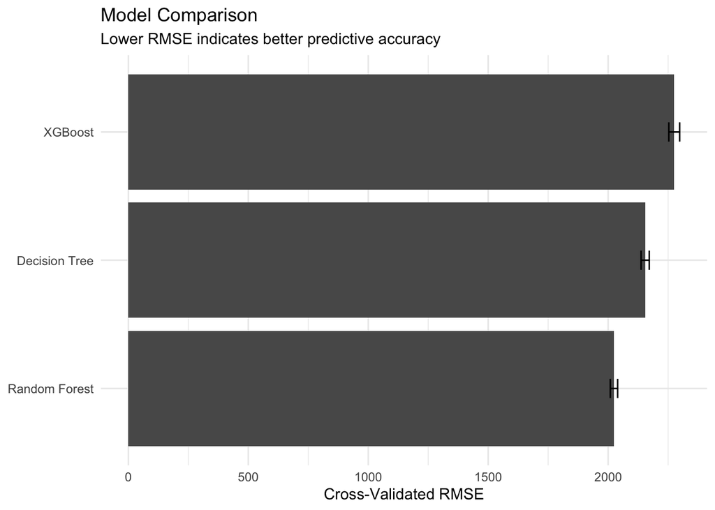

Ten-fold cross-validated RMSE across the three tree-based methods.

```r
cv_comparison |>
  filter(.metric == "rmse") |>
  ggplot(aes(x = reorder(model, mean), y = mean)) +
  geom_col() +
  geom_errorbar(
    aes(ymin = mean - std_err, ymax = mean + std_err),
    width = 0.15
  ) +
  coord_flip() +
  labs(
    x = NULL,
    y = "Cross-Validated RMSE",
    title = "Model Comparison",
    subtitle = "Lower RMSE indicates better predictive accuracy"
  ) +
  theme_minimal()
```

The preferred model is the one with the **lowest cross-validated RMSE**, considered together with (R^2), MAE, interpretability, and the business objective. Cross-validation is more informative than selecting a model based on training accuracy because every candidate is repeatedly evaluated on held-out folds.

# 7 6. Feature Importance

## 7.1 Prompt

> **Produce a chart that shows the importance of features. Is the result reasonable? Why or why not?**

```r
rf_fit <- fit(rf_wf, data = retail_train)
```

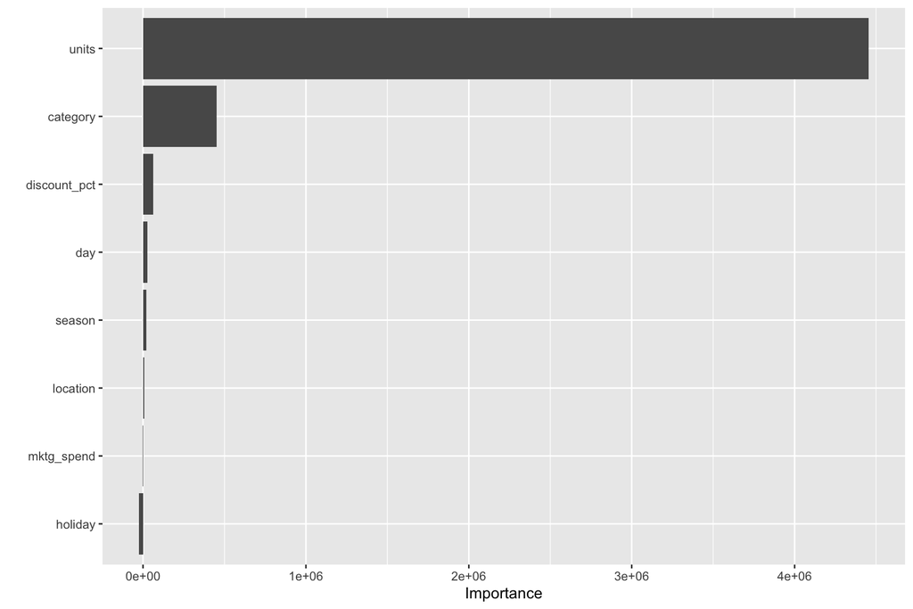

Permutation feature importance from the fitted random forest.

```r
rf_fit |>
  extract_fit_engine() |>
  vip(num_features = 15)
```

Feature importance measures how useful predictors are to the fitted model. If variables such as units sold, marketing spend, discounts, or product/store characteristics rank highly, that is substantively plausible because they are directly connected with transaction performance.

However, importance is **predictive rather than causal**. A high-importance feature should not automatically be interpreted as something that causes revenue to increase.

# 8 7. Decision Tree Pruning

## 8.1 Prompt

> **Fit decision trees across `cost_complexity` values of `c(0.0001, 0.001, 0.005, 0.01, 0.05, 0.10)`. Plot train vs. test performance across all values. At what value does test performance peak? What happens to training performance at the same value?**

## 8.2 Why RMSE and (R^2) replace AUC

AUC requires a categorical outcome with positive and negative classes. Revenue is continuous, so using AUC would not be valid for this AO. I use **RMSE** as the primary pruning criterion and report (R^2) as a complementary measure.

## 8.3 Pruning Function

```r
fit_tree_cp <- function(cp_value) {

  spec <- decision_tree(
    cost_complexity = cp_value,
    tree_depth = 30,
    min_n = 2
  ) |>
    set_engine("rpart") |>
    set_mode("regression")

  wf <- workflow() |>
    add_recipe(tree_rec) |>
    add_model(spec)

  fitted <- fit(wf, data = retail_train)

  train_pred <- predict(fitted, retail_train) |>
    bind_cols(retail_train |> select(revenue))

  test_pred <- predict(fitted, retail_test) |>
    bind_cols(retail_test |> select(revenue))

  train_rmse <- rmse_vec(
    truth = train_pred$revenue,
    estimate = train_pred$.pred
  )

  test_rmse <- rmse_vec(
    truth = test_pred$revenue,
    estimate = test_pred$.pred
  )

  train_rsq <- rsq_vec(
    truth = train_pred$revenue,
    estimate = train_pred$.pred
  )

  test_rsq <- rsq_vec(
    truth = test_pred$revenue,
    estimate = test_pred$.pred
  )

  leaves <- fitted |>
    extract_fit_engine() |>
    pluck("frame") |>
    filter(var == "<leaf>") |>
    nrow()

  tibble(
    cp = cp_value,
    train_rmse = train_rmse,
    test_rmse = test_rmse,
    train_rsq = train_rsq,
    test_rsq = test_rsq,
    leaves = leaves
  )
}
```

## 8.4 Fit All Requested Cost-Complexity Values

```r
cp_values <- c(0.0001, 0.001, 0.005, 0.01, 0.05, 0.10)

pruning_results <- map_dfr(cp_values, fit_tree_cp)

pruning_results
```

| cp | train_rmse | test_rmse | train_rsq | test_rsq | leaves |
| --- | --- | --- | --- | --- | --- |
| 1e-04 | 1196.748 | 2576.976 | 0.7802282 | 0.2089190 | 1260 |
| 1e-03 | 1782.529 | 2184.437 | 0.5124274 | 0.3254732 | 51 |
| 5e-03 | 1921.749 | 2129.282 | 0.4332916 | 0.3487425 | 13 |
| 1e-02 | 1986.048 | 2145.714 | 0.3947345 | 0.3368563 | 8 |
| 5e-02 | 2132.512 | 2199.202 | 0.3021705 | 0.3016152 | 3 |
| 1e-01 | 2233.323 | 2292.682 | 0.2346336 | 0.2411870 | 2 |

## 8.5 Train vs. Test RMSE

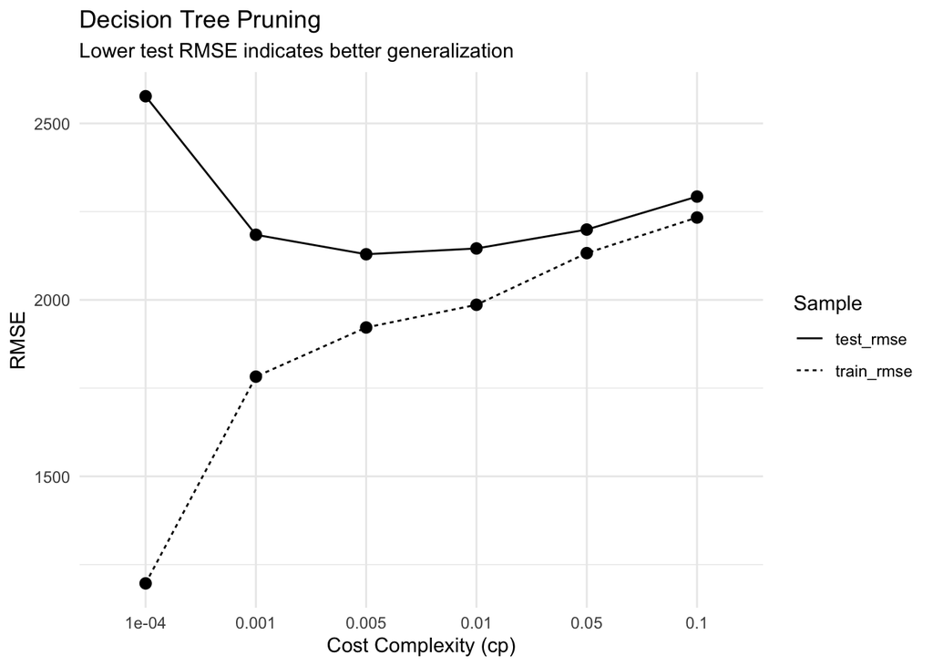

Training and test RMSE across requested cost-complexity values.

```r
pruning_results |>
  select(cp, train_rmse, test_rmse) |>
  pivot_longer(
    cols = c(train_rmse, test_rmse),
    names_to = "sample",
    values_to = "rmse"
  ) |>
  ggplot(aes(x = factor(cp), y = rmse, group = sample, linetype = sample)) +
  geom_line() +
  geom_point(size = 2.5) +
  labs(
    x = "Cost Complexity (cp)",
    y = "RMSE",
    linetype = "Sample",
    title = "Decision Tree Pruning",
    subtitle = "Lower test RMSE indicates better generalization"
  ) +
  theme_minimal()
```

## 8.6 Train vs. Test (R^2)

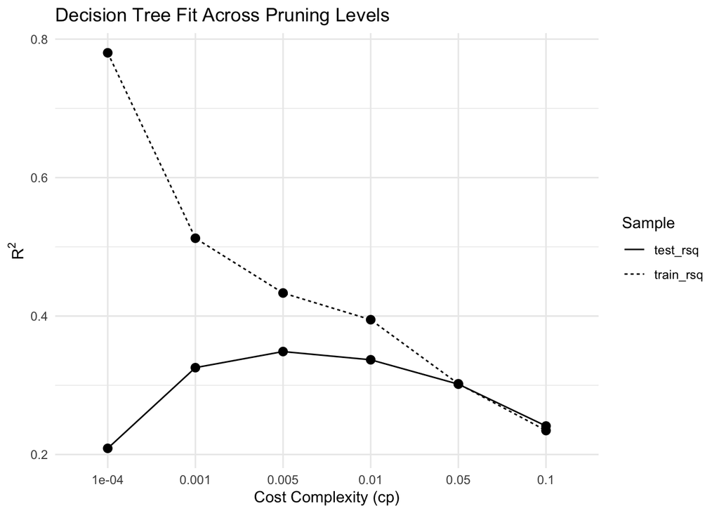

Training and test R-squared across requested cost-complexity values.

```r
pruning_results |>
  select(cp, train_rsq, test_rsq) |>
  pivot_longer(
    cols = c(train_rsq, test_rsq),
    names_to = "sample",
    values_to = "rsq"
  ) |>
  ggplot(aes(x = factor(cp), y = rsq, group = sample, linetype = sample)) +
  geom_line() +
  geom_point(size = 2.5) +
  labs(
    x = "Cost Complexity (cp)",
    y = expression(R^2),
    linetype = "Sample",
    title = "Decision Tree Fit Across Pruning Levels"
  ) +
  theme_minimal()
```

## 8.7 Optimal `cp`

```r
optimal_cp <- pruning_results |>
  slice_min(test_rmse, n = 1, with_ties = FALSE)

optimal_cp
```

| cp | train_rmse | test_rmse | train_rsq | test_rsq | leaves |
| --- | --- | --- | --- | --- | --- |
| 0.005 | 1921.749 | 2129.282 | 0.4332916 | 0.3487425 | 13 |

The optimal requested `cp` is the value producing the **lowest test RMSE**. At this point I compare training RMSE with test RMSE. A more complex tree can continue improving its fit to training observations even after its performance on unseen observations begins to deteriorate.

# 9 8. Leaf Nodes at the Optimal `cp`

## 9.1 Prompt

> **At the optimal `cp`, how many leaf nodes does the tree have? Use `extract_fit_engine() |> pluck("frame") |> filter(var == "<leaf>") |> nrow()`.**

```r
best_cp <- optimal_cp$cp[[1]]

optimal_tree_spec <- decision_tree(
  cost_complexity = best_cp,
  tree_depth = 30,
  min_n = 2
) |>
  set_engine("rpart") |>
  set_mode("regression")

optimal_tree_wf <- workflow() |>
  add_recipe(tree_rec) |>
  add_model(optimal_tree_spec)

optimal_tree_fit <- fit(optimal_tree_wf, data = retail_train)

optimal_leaf_nodes <- optimal_tree_fit |>
  extract_fit_engine() |>
  pluck("frame") |>
  filter(var == "<leaf>") |>
  nrow()

optimal_leaf_nodes
```

```
[1] 13
```

The rendered result above gives the exact number of terminal leaf nodes in the best tree among the requested pruning values.

# 10 9. Explaining Overfitting to a Marketing Manager

## 10.1 Prompt

> **In plain English, explain why a tree with 200 leaf nodes might perform worse on new customers than a tree with 15 leaf nodes even though it was more accurate on the training data.**

## 10.2 Response

Imagine that the 200-leaf tree creates extremely specific customer rules. It might learn that a particular combination of discount, store, product category, day, and marketing spend was associated with a certain revenue outcome in the historical dataset. Some of those rules may represent genuine customer patterns, but others may simply capture random quirks in the sample.

The 15-leaf tree is forced to focus on broader and more repeatable patterns. It may make a few more mistakes on customers it has already seen, but its rules can transfer more reliably to new transactions.

This is the difference between **memorizing historical customers and learning patterns that generalize**. Pruning deliberately accepts some loss of training accuracy when that tradeoff produces better predictions for future customers.

**ImportantMarketing interpretation**

The most complicated model is not automatically the most useful model. The goal is not to explain every fluctuation in historical sales; it is to make reliable decisions about customers and transactions the retailer has not seen yet.

# 11 10. Overall Interpretation

**Decision Tree**

**Strengths**

- Easy to visualize and communicate
- Handles nonlinear relationships
- Captures interactions automatically
- Requires relatively little preprocessing

**Limitation**

A single tree can be unstable and prone to overfitting.

**Random Forest**

**Strengths**

- Reduces variance by averaging many trees
- Usually generalizes better than one tree
- Provides feature importance

**Limitation**

The combined forest is harder to explain as a single set of business rules.

**XGBoost**

**Strengths**

- Sequentially corrects prediction errors
- Can capture complex nonlinear patterns
- Often provides strong predictive accuracy

**Limitation**

It introduces more tuning parameters and is less directly interpretable than one decision tree.

The model comparison illustrates an important lesson from the Trees and Ensembles module: **interpretability and predictive performance are related but distinct objectives**. A single tree provides a clear description of decision rules, while ensemble methods can improve prediction by combining many trees.

# 12 11. Final Reflection

This exercise changed how I think about decision trees. The value of a tree is not simply that it can split data into groups. The more important idea is controlling the balance between **model complexity and generalization**.

The pruning exercise makes this visible. A very flexible tree can continue reducing training error by creating increasingly specific leaves, but those additional rules can eventually represent noise rather than stable retail behavior. Cost-complexity pruning provides a systematic way to reduce that risk.

Comparing the decision tree with random forest and XGBoost also demonstrates why ensembles are powerful. Random forests reduce the instability of individual trees by averaging many of them, while boosting builds trees sequentially to correct previous errors. The best method should ultimately be selected using performance on unseen data rather than how closely it fits the training sample.

For the retail project, the most useful outcome is therefore not just a prediction of revenue. The analysis also provides a framework for understanding **which information contributes most to predictive performance and how much complexity is justified when the goal is making decisions about future retail activity**.

# Appendix

## 12.1 Course Sources

- Trees and Ensembles Codebook: https://jaejungca.github.io/trees-ensembles/m06_trees_ensembles.html
- Trees and Ensembles GitHub Repository: https://github.com/jaejungca/trees-ensembles

## 12.2 Project Publication Links

- **GitHub Repository:** https://github.com/mjshawell/IBM-6540-IBM-6300/tree/main
- **Published HTML / GitHub Pages:** https://mjshawell.github.io/IBM-6540-IBM-6300/Mickyas-Shawel-M09-Trees-Group-Project.html